# Creating **Static and Interactive** Maps in R for Beginners

Giada Leone

Published 06/12/2021

### Tutorial Aims

##### 1. Understanding the importance of open access data

##### 2. Data preparation and wrangling for spatial visualisation

##### 3. Creating basic *static* maps with point data using ggplot2

##### 4. Creating *interactive* maps using the leaflet package

### Introduction

#### This tutorial is aimed at people who have some experience in using R and would like to try **spatial data visualisation** by using R as a GIS like software using specific packages. R is very powerful due to its wide applications in statistics, modelling, data visualisation and spatial data. In this tutorial we will be focusing on a specific type of spatial data: *point data*, and different ways to visualise it without diving into the theory behind more complex spatial objects such as lines and polygons.

#### This table summarises the key features of these different types of *vector data*

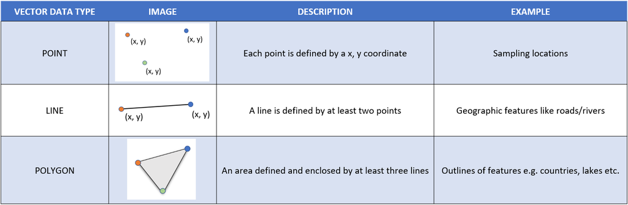

#### If you are interested in other types of spatial data have a look at the supplementary material at the end of the tutorial.

#### There are many different ways to go about spatial mapping in R, and today you will learn one of these ways. To successfully plot spatial point data, the observations in the data frame must be associated with a set of X and Y coordinates which correspond to latitude and longitude.

#### In this tutorial we will be using a dataset from provided by the Marine Conservation Society which collates information from beach clean surveys carried out around the UK. The Great British Beach Clean is a volunteer initiative which encourages social engagement for conservation efforts. The data set includes count data collected for different litter categories for surveys between 2008 - 2018.

#### Unfortunately this dataset has not been made publicly available and so you will only be able to access it by downloading my repository. There are benefits to open access data, for example, they encourage transparency amongst the scientific community. This data was provided to me individually for my dissertation project. Considering this data is collected by a charity, I hope that in future years the data can be made publically available which can also promote awareness of the extent of the littering problem we as communities create. Some sources for open access data have been provided in the at the end of the tutorial.

#### Here is a quick introduction to spatial data

[figure not shown]

#### Let’s set up your project folder/ directory

Once you open Rstudio you need to create a project to include all of the files related to this tutorial by clicking on the create a project symbol in the global toolbar at the top of an Rstudio window. Click on ‘new directory’ and ‘new project’, save the folder on your desktop and give it a descriptive name such as ‘maps_tutorial’.

Your Rstudio project will open up and now you can create a new script by typing ‘ctrl + shift + N’ on windows or ‘command + shift + N’ on Mac or simply by using the global toolbar.

#### Downloading the files

To download the necessary dataset you can clone or download the [repository](https://github.com/EdDataScienceEES/tutorial-giadaleone99) by clicking on the green ‘Code’ button and then clicking on ‘download ZIP’. Next you can unzip the folder and move the data file ‘beachwatch_data.csv’ into the project folder/directory that you created previously. This data is provided by the [Marine Conservation Society](https://www.mcsuk.org/) as part of the Great British Beach Clean initiative.

#### Required packages

We will be using the `tidyverse` to do data wrangling and preparing the dataset, it also includes the `ggplot2` package which we will use for visualisation of point data.

The `janitor` package is a useful tool to clean datasets which will come in handy when handling public datasets which may have unorganised column names.

The `leaflet` package allows us to create interactive and informative maps.

If you have never used these packages before you will need to install them by using the `install.packages("packagename")` function and include the names within the "" before loading them with the `library(packagename)` function.

```r
# Libraries ----
# install.packages("tidyverse")

library(tidyverse)  # Data wrangling & includes ggplot2
library(janitor)    # Cleaning datasets
library(ggthemes)   # Themes for ggplot2
library(leaflet)    # Interactive map
```

### Importing the dataset

Here we are importing the file ‘beachwatch_data.csv’ which you previously moved to your directory. We use the `read.csv()` function and assign the dataframe to object called ‘beaches’.

Note that if you previously saved the data file in a sub-folder you will have to specify the file-path to import the data. For example, if you moved the csv file to a folder names ‘data’ within the repository, you should write `beaches <- read.csv(data/beachwatch_data.csv")`

```r
beaches <- read.csv("beachwatch_data.csv")
```

Now, let’s have a look at the imported data by clicking on the object you created in your environment pane!

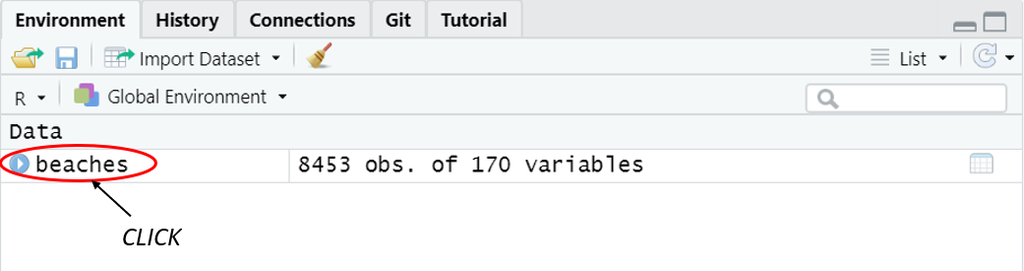

A new pane should open, and should look something like this

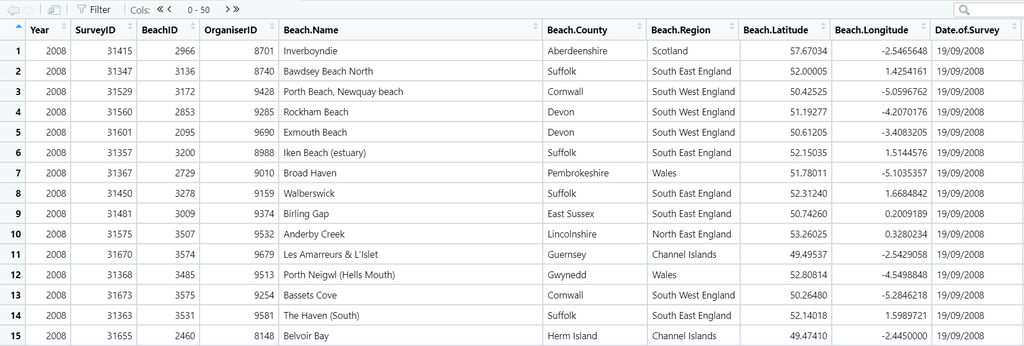

You should be able to scroll to the right and see some of the different categories of litter collected. Other important columns in the dataset include the year when the survey was carried out, where the beach is located such as region and county as well as specific beach longitude and latitude.

In the next section, we will be removing some of the columns we do not need, to declutter the data. We will be focusing on cigarette related litter and so we will keep the relevant rows.

### Preparing the data

```r
# Cleaning data frame column names
beaches <- beaches %>% clean_names()

# Viewing column names and associated column numbers
colnames(beaches)

# Deleting unused columns
beaches <- select(beaches,-seq(12, 109), -seq(112, 170))

# Dropping columns which have NA values
beaches <- drop_na(beaches)
```

Changing data types: if variables are characters we are converting them to factors or ‘categorical’ data types, and if variables are integers we convert them to numeric. This is important for subsequent steps to work. R often requires variables to be a specific data type.

```r
# Checking data types
str(beaches)

# Changing data types
beaches <- beaches %>% mutate_if(is.character, as.factor) %>%
                       mutate_if(is.integer, as.numeric)
```